# Portfolio 6: FSA

2024-02-05

Portfolio assignment questions are at the end of the CatchCurve and the Depletion function sections. There is not a portfolio assignment with the Weight-Length example, but the code is here if you want to try it! There are a total of four questions.

## Load in the necessary pacakges for all three examples

```r
knitr::opts_chunk$set(echo = TRUE, message = FALSE, warning = FALSE, results = FALSE)

#the main package
library(FSA)
#this package contains data compatible with this package
library(FSAdata)
#for data manipulation
library(tidyverse)
library(stringr)
library(janitor)
```

FSA: Fisheries Stock Assessment

This portfolio covers a lot of the package’s main uses, though there are certainly more. A lot of useful data corresponds with it.

## Weight-length example

load in the data, which comes from the FSAdata package above

```r
data(InchLake2)
```

clean data for example

```r
#let's look at the Bluegill data, which was a catch and release sample from a lake in Wisconsin.

#this data has fish length in inches and weight in grams. recall for relative weights you need to be fully in english or metric units.

#convert lengths to mm in a new column called length_mm
InchLake2$length_mm <- round(InchLake2$length*25.4,0)

#look specifically at Bluegill fish, and from the year 2007, to get a snapshot of how the population was doing at that particular time
bluegill_2007 <- InchLake2 %>%
  filter(species == "Bluegill", year == "2007")
```

compute relative weight using wrAdd(),

```r
# you can manually compute relative weight (see the vignette for that), but FSA gives you a tool to do that more easily:

#wrAdd() calculates the relative weight for each fish based on the standard weight equation for that species
bluegill_2007_weights <- wrAdd(weight~length_mm+species, data=bluegill_2007) #calculates relative weight

#add to the dataframe
bluegill_2007 <- bluegill_2007 %>%
  mutate(relative_weight = bluegill_2007_weights)
```

interpret what the relative weights mean

```r
wr_2007 <- mean(bluegill_2007$relative_weight, na.rm = TRUE)
wr_2007

#relative weight below 100 indicates the fish/population is skinnier than expected for that species, indicating a potentially unhealthy population and environmental conditions that aren't favorable
#relative weight above 100 indicates the fish/population is fatter than expected for that species, indicating a healthy population and favorable environmental conditions
```

In this case, the mean relative weight is below 100 (88.67), which suggests the bluegill population weighs less than expected. This brings up concerns for the population’s health and indicates a closer look should probably be taken at the surrounding environmental conditions.

find the average relative weight by size class

```r
#for bluegill research groups them into the following classes:
## <8 cm
## <15 cm
## <20 cm
## <25 cm
## <30 cm
#approximate length at maturity for bluegill is 15cm, so the first two size classes are juveniles

#categorize each fish into its size class
bluegill_2007 <- bluegill_2007 %>%
  mutate(class = ifelse(length_mm < 80, "young_of_year", ifelse(length_mm < 150, "juvenile", ifelse(length_mm < 200, "adult_1", ifelse(length_mm < 250, "adult_2", "adult_3")))))

#the relative weight function doesn't work for fish in the young of year class for this species (they're too short), so we can compare juveniles to different classes of adults

bluegill_2007_summary <- bluegill_2007 %>%
  group_by(class) %>%
  summarize(mean_relative_weight = mean(relative_weight, na.rm = TRUE))

bluegill_2007_summary
```

Skinny fish!

## CatchCurve example

let’s grab the data and process it!

We need a dataframe that contains age and catch (both are numerics)

```r
#can use this function from FSAdata to find data that is compatible with the function
help.search("Catch curve", package=c("FSAdata","FSA"))

#we are going to use data of estimated catch-at-age for Gulf Menhaden from 1964-2004
data<-FSAdata::Menhaden1 %>%
  #pivot the data to get it in the required format
  pivot_longer(cols = age0:age6, names_to = "age", values_to = "ct") %>%
  #then use group by and summarize to get one total catch value by age class
  group_by(age) %>% summarise(catch=sum(ct))

#use string manipulations to remove the leading age_ from the values in the age column
data$age<-str_replace_all(data$age, "age", "")

#convert columns to numerics
data$age<-as.numeric(data$age)

#take the log of catch
data$logct <- log(data$catch)

#examine the structure of the dataframe
str(data)
```

Plot the catch curve for this data to assess which ages fall on the descending limb of the catch curve.

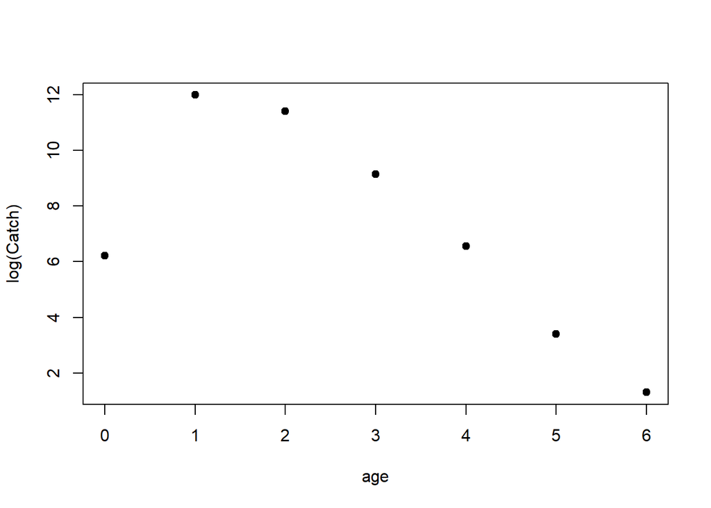

```r
plot(logct~age,data=data,ylab="log(Catch)",pch=19)
```

Most ages (after 1) are on the descending limb of the catch curve.

Non-weighted regression

Now, you can use this information in the catchCurve function

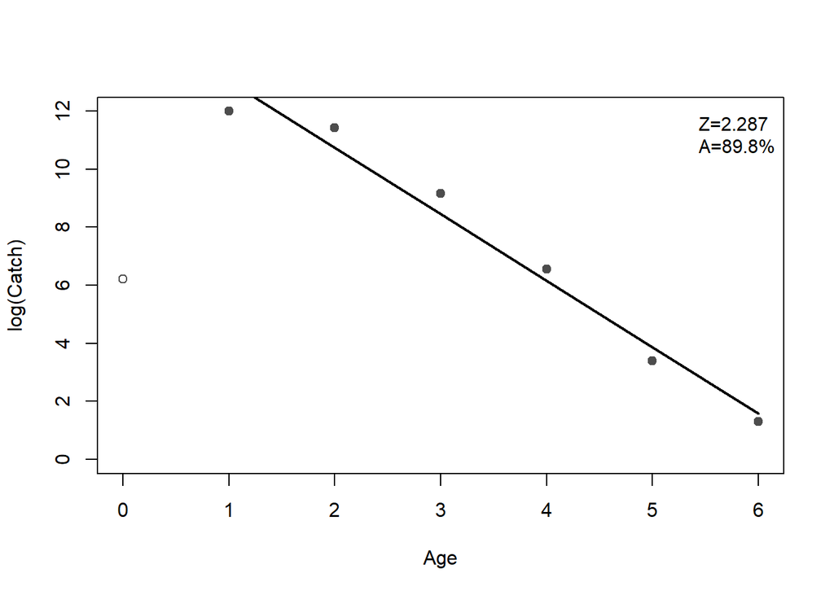

```r
#we will use years 1-6
results <- FSA::catchCurve(catch~age,data=data,ages2use=1:6)

#show the estimated values of Z and A (and std. deviation)
#Z is the instantaneous mortality rate (think slope of line)
#A is the annual mortality rate
summary(results)

#show the confidence intervals associated with these values
confint(results)

#plot the points with the results for Z and A
plot(results)
```

Weighted Regression

The use of catchCurve in the previous chunk assigned equal weight to fish of all ages, but Maceina and Bettoli (1998) suggested that a weighted regression should be used with the catch-curve method in order to reduce the relative impact of older ages with fewer fish. The use of use.weights=TRUE satisfies this.

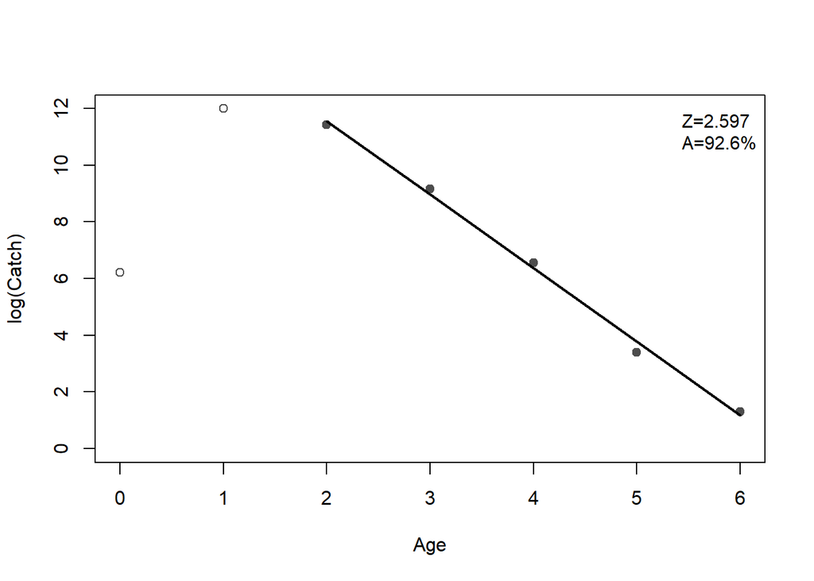

```r
weighted_results <- FSA::catchCurve(catch~age,data=data,
                                    ages2use=2:6,use.weights=TRUE)

summary(weighted_results)

confint(weighted_results)

plot(weighted_results)
```

## Portfolio Question:

How do the estimates of Z and A change between between the weighted and non-weighted regressions? How does the confidence interval change?

Z and A increase some with the weighted regressions, which is interesting, especially since we’re shifting how the models incorporate older fish. There is a lower standard error, though, leading to a smaller confidence interval.

## Depletion example

Welcome to the FSA function depletion()!!!!

This function can be used to estimate the initial population size (N0) for a closed population (aka no immigration, emmigration, mortatlity, or recruitment).

There are three methods for estimating N0: the Leslie Method, DeLury Method, and K-Pass Method

load in the depletion data!

If you go to the help window and click on the depletion package, you will also find details about the Leslie and DeLury methods.

```r
help.search("depletion", package=c("FSAdata","FSA"))

#we are going to use the catch and effort snapper data
#there are 3 different species within this data set, all with the same effort. We are going to focus on Pristipomoides zonatus species.
#effort = fishing effort (line-hours of a bottom hand-line)

snapper <- FSAdata::Pathfinder
snapper_pzonatus <-snapper %>% clean_names()
```

```r
snapper_pauricilla <-snapper %>% clean_names()
```

Now to start with the Leslie Method!

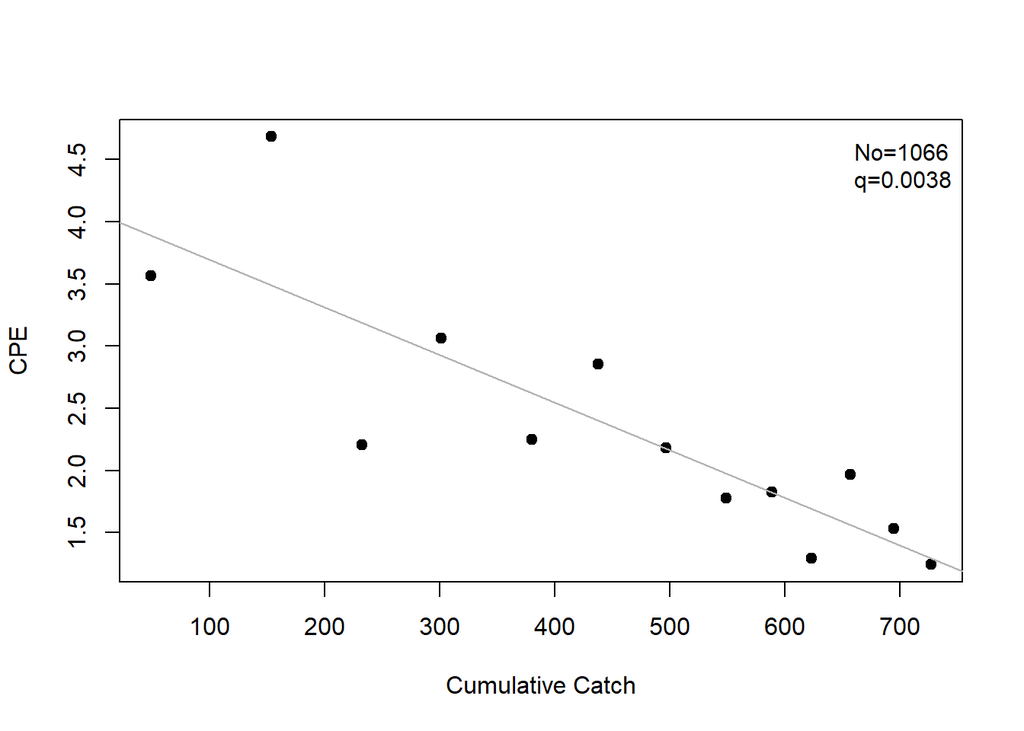

```r
#grab the data use the depletion() to calculate N0 and q
leslie <- with(snapper_pzonatus, depletion(pzonatus,effort,method="Leslie",Ricker.mod = TRUE)) #the ricker.mod is a modification that is used within the equation
summary(leslie)
#remember that N0 = initial population size and q = catchability coefficient or the fraction of the population that is removed by one unit of fishing effort

#find the confidence intervals of this data
confint(leslie)

#plot it
plot(leslie)
```

The initial population size of the Pristipomoides zonatus is 1066.

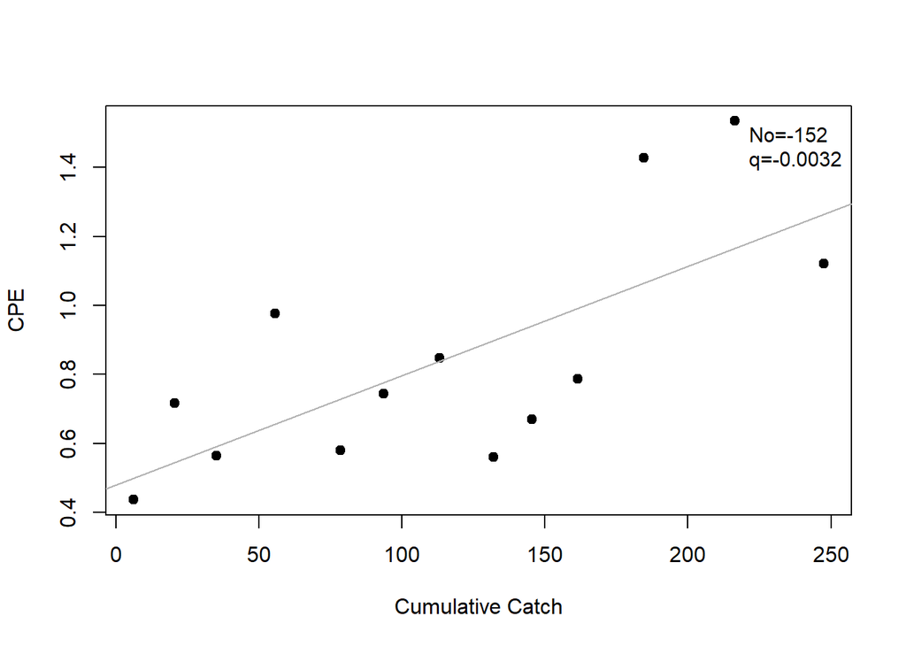

```r
#grab the data use the depletion() to calculate N0 and q
leslie2 <- with(snapper_pauricilla, depletion(pauricilla,effort,method="Leslie",Ricker.mod = TRUE)) #the ricker.mod is a modification that is used within the equation
summary(leslie2)
#remember that N0 = initial population size and q = catchability coefficient or the fraction of the population that is removed by one unit of fishing effort

#find the confidence intervals of this data
confint(leslie2)

#plot it
plot(leslie2)
```

Now for the DeLury Method!

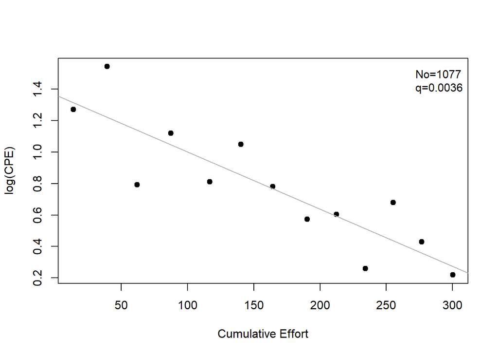

```r
#we will use the same set of data and species for this method in order to compare/contrast them
delury <- with(snapper_pzonatus, depletion(pzonatus, effort, method="Delury", Ricker.mod = TRUE))
summary(delury)

confint(delury)

plot(delury)
```

The DeLury Method finds that the inital population size of Pristipomoides zonatus is 1077, so 11 more than the Leslie Method as well as a slight decrease in q!

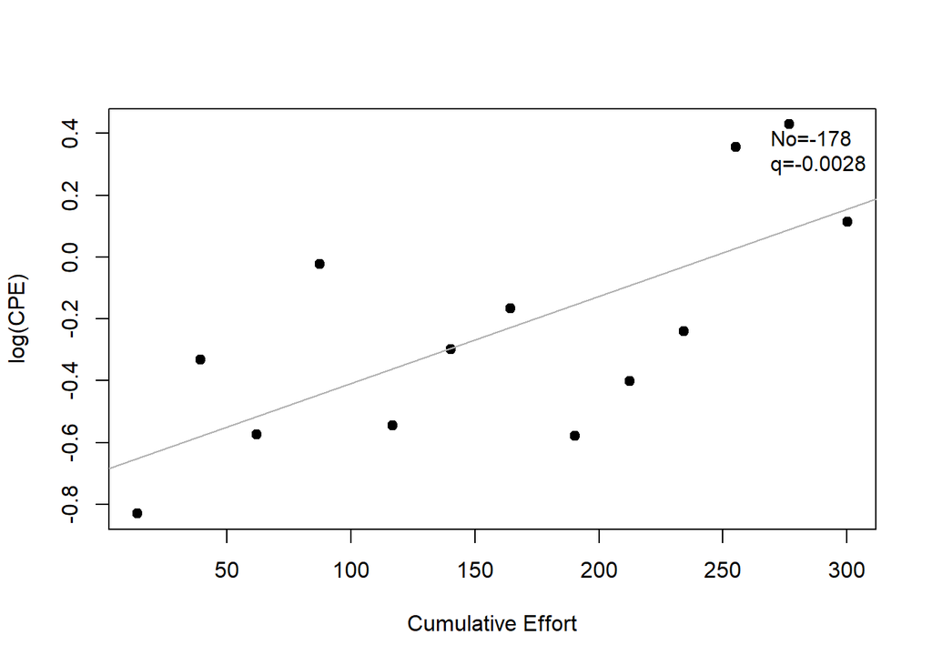

```r
#we will use the same set of data and species for this method in order to compare/contrast them
delury2 <- with(snapper_pauricilla, depletion(pauricilla, effort, method="Delury", Ricker.mod = TRUE))
summary(delury2)

confint(delury2)

plot(delury2)
```

Now for the K-Pass Method

```r
#again, we are going to use the snapper Pristipomoides zonatus data, but this time we only need catch data
#for this method, we will still get N0 but will also get p which is probability of capture

k_pass <- with(snapper_pzonatus, removal(pzonatus))
summary(k_pass)

confint(k_pass)
```

The K-Pass Method determined that N0 is 985, but does have an upper bound of 1077. p=0.1

```r
#for this method, we will still get N0 but will also get p which is probability of capture

k_pass2 <- with(snapper_pauricilla, removal(pauricilla))
summary(k_pass2)

confint(k_pass2)
```

This actually had a higher N0 value than I was expecting. K-pass didn’t work as well here, which makes sense; it is more difficult to see a trend with *Pauricilla*.

## Portfolio Questions:

Grab a new set of data and use the Leslie, DeLury, and K-Pass methods to calculate the initial population size! Answer the following questions:

1. Compare and contrast the initial population sizes between the three methods

Overall, K-Pass tends to estimate the lowest inital N0 of the three, while DeLury tends to estimate the highest, though it of course depends on the dataset.

2. Why are the Leslie and DeLury methods not valid at estimating N0?

The Leslie and DeLury methods have a much larger standard error and bigger confidence interval than the K-Pass method, which does make me question the results, though the estimates they provide still seem roughly in the ballpark of each other.

3. What values can you look at to determine the reliability of the data? (Hint: Think back to what we learned about statistics in 206)

The standard errors and confidence intervals that the models provide are useful for assessing the reliability of the data and how well they fit. A visual inspection of the data and graphs also provides a good sanity check, especially if you have a good understanding of the values that are typical of a species.